# Assignment III

February 11, 2019

> Please submit your answers by 5:59 pm on Feb 11, 2019. Remember to show your work. In other words, always use echo=TRUE for the R code chunks that you provide. NOTE - All plots must show proper title, axis lables, and any legends used. Points will be deducted otherwise.

## Question 1: Simple Linear Regression

We are going to work with the dataset bike_data.csv (provided in Files->Assignments->Assignment_3). This dataset has been dowloaded from Kaggle, which is an online prediction contest website (see https://www.kaggle.com/c/bike-sharing-demand/data). The data is essentially the log of hourly bike rentals in a city over two years. The following is the codebook:

. datetime - hourly date + timestamp  
. season - 1 = spring, 2 = summer, 3 = fall, 4 = winter  
. holiday - whether the day is considered a holiday  
. workingday - whether the day is neither a weekend nor holiday  
. weather - 1: Clear, Few clouds, Partly cloudy, Partly cloudy , 2: Mist + Cloudy, Mist + Broken clouds, Mist + Few clouds, Mist , 3: Light Snow, Light Rain + Thunderstorm + Scattered clouds, Light Rain + Scattered clouds , 4: Heavy Rain + Ice Pallets + Thunderstorm + Mist, Snow + Fog  
. temp - temperature in Celsius  
. atemp - “feels like” temperature in Celsius  
. humidity - relative humidity  
. windspeed - wind speed . . casual - number of non-registered user rentals initiated  
. registered - number of registered user rentals initiated  
. count - number of total rentals

First, we need to do some preprocessing. Specifically, we need to process the year variable and remove all observations with weather == 4 (these are outliers and need to be be removed).

```r
# set up
rm(list=ls())
library(plyr)
library(dplyr)
library(lubridate)
library(ggplot2)

# Read the dataset in
bike_data <- read.csv("bike_data.csv", header = TRUE)

# Preprocess
bike_data <- bike_data %>% mutate(datetime_f = mdy_hm(datetime)) %>%
  mutate(year = as.factor(year(datetime_f))) %>%
  mutate(weather = as.factor(weather)) %>%
  filter(weather != "4")
```

1. Perform the following simple linear regression: count ~ temperature. What are the coefficients and their 95% confidence intervals?  
   Ans.

```r
## Insert code below
m.bike_data <- lm(count ~ temp, data= bike_data)

summary(m.bike_data)
```

```
##
## Call:
## lm(formula = count ~ temp, data = bike_data)
##
## Residuals:
##     Min      1Q  Median      3Q     Max
## -293.33 -112.35  -33.35   78.82  741.44
##
## Coefficients:
##             Estimate Std. Error t value Pr(>|t|)
## (Intercept)   6.0081     4.4402   1.353    0.176
## temp          9.1720     0.2048  44.784   <2e-16 ***
## ---
## Signif. codes:  0 '***' 0.001 '**' 0.01 '*' 0.05 '.' 0.1 ' ' 1
##
## Residual standard error: 166.5 on 10883 degrees of freedom
## Multiple R-squared:  0.1556, Adjusted R-squared:  0.1555
## F-statistic:  2006 on 1 and 10883 DF,  p-value: < 2.2e-16
```

```r
coef(m.bike_data)
```

```
## (Intercept)        temp
##    6.008118    9.172048
```

```r
confint(m.bike_data)
```

```
##                 2.5 %    97.5 %
## (Intercept) -2.695529 14.711765
## temp         8.770590  9.573505
```

```r
#intercept = βo
#slope = β1
#βo = 6.01, β1 = 9.17
#(95% CI, 8.77-9.57, p<0.001)
```

2. Interpret your results in terms of increase or decrease in temperature. Mention specifically what is the meaning of the intercept and the direction and magnitude of the association between temperature and count.

# intercept: intersection at the axis representing the mean value of y when x = 0

βo = 6.01 #slope: steepness of a line representing the change in y as x changes. β1 = 9.17 #(95% CI, 8.77-9.57, p<0.001). #When temperature is zero degrees Celsius, the average bike rentals are 6.

Ans.

An increase in temperature by 1 degree Celsius is correlated with an increase in bike rentals by 9.

3. Using mutate, create a new variable temp_f which is Farenheit representation of values in the temp variable. Perform the regression count ~ temp_f and interpret the results. What conclusions can you draw from this experiment?  
   Ans.

```r
## Insert code below

bike_data <- mutate(bike_data, temp_f = (temp*(9/5) + 32))

m.bike_data <- lm(count ~ temp_f, data= bike_data)

summary(m.bike_data)
```

```
##
## Call:
## lm(formula = count ~ temp_f, data = bike_data)
##
## Residuals:
##     Min      1Q  Median      3Q     Max
## -293.33 -112.35  -33.35   78.82  741.44
##
## Coefficients:
##              Estimate Std. Error t value Pr(>|t|)
## (Intercept) -157.0505     7.9465  -19.76   <2e-16 ***
## temp_f         5.0956     0.1138   44.78   <2e-16 ***
## ---
## Signif. codes:  0 '***' 0.001 '**' 0.01 '*' 0.05 '.' 0.1 ' ' 1
##
## Residual standard error: 166.5 on 10883 degrees of freedom
## Multiple R-squared:  0.1556, Adjusted R-squared:  0.1555
## F-statistic:  2006 on 1 and 10883 DF,  p-value: < 2.2e-16
```

```r
coef(m.bike_data)
```

```
## (Intercept)      temp_f
## -157.050506    5.095582
```

```r
confint(m.bike_data)
```

```
##                  2.5 %      97.5 %
## (Intercept) -172.62703 -141.473980
## temp_f         4.87255    5.318614
```

```r
#intercept = βo
#slope = β1
#βo = -157.05, β1 = 5.1
#(95% CI, 4.87-5.32, p<0.001)

#At zero degrees Fahrenheit, there is an average decrease of 157 bike rentals. An increase in temperature by 1 degree Fahrenheit is correlated with an increase in bike rentals by 5. Since the intercept is large, this value may not be of significance and can be difficult to interpret.
```

## Question 2: Multiple Linear Regression - I

On the same datasetas Q1, perform the following multiple linear regression: count ~ temp + season + humidity + weather + year. Keep season and weather as categorical variables. Interpret your results through the following means :

1. what is the intercept and what does it mean? Ans.

```r
## Insert code below
bike_data <- bike_data %>%
  mutate(season = as.factor(season), weather = as.factor(weather))

m2.bike_data <-lm(count~temp + season + humidity + weather + year, data = bike_data)

summary(m2.bike_data)
```

```
##
## Call:
## lm(formula = count ~ temp + season + humidity + weather + year,
##     data = bike_data)
##
## Residuals:
##     Min      1Q  Median      3Q     Max
## -332.13  -98.50  -24.59   71.56  669.69
##
## Coefficients:
##              Estimate Std. Error t value Pr(>|t|)
## (Intercept)  98.49594    7.33550  13.427  < 2e-16 ***
## temp         10.43201    0.31043  33.606  < 2e-16 ***
## season2       4.71765    5.24017   0.900  0.36799
## season3     -29.10223    6.64854  -4.377 1.21e-05 ***
## season4      66.98554    4.39278  15.249  < 2e-16 ***
## humidity     -2.73308    0.08594 -31.800  < 2e-16 ***
## weather2     11.34183    3.48729   3.252  0.00115 **
## weather3     -7.37635    5.78648  -1.275  0.20242
## year2012     75.87791    2.88950  26.260  < 2e-16 ***
## ---
## Signif. codes:  0 '***' 0.001 '**' 0.01 '*' 0.05 '.' 0.1 ' ' 1
##
## Residual standard error: 149.6 on 10876 degrees of freedom
## Multiple R-squared:  0.3189, Adjusted R-squared:  0.3184
## F-statistic: 636.7 on 8 and 10876 DF,  p-value: < 2.2e-16
```

```r
coef(m2.bike_data)
```

```
## (Intercept)        temp     season2     season3     season4    humidity
##   98.495944   10.432008    4.717650  -29.102227   66.985542   -2.733076
##    weather2    weather3    year2012
##   11.341830   -7.376353   75.877913
```

```r
confint(m2.bike_data)
```

```
##                  2.5 %     97.5 %
## (Intercept)  84.117030 112.874857
## temp          9.823518  11.040497
## season2      -5.554035  14.989334
## season3     -42.134585 -16.069869
## season4      58.374886  75.596197
## humidity     -2.901543  -2.564609
## weather2      4.506115  18.177544
## weather3    -18.718903   3.966197
## year2012     70.213974  81.541852
```

```r
#Intercept = βo
#βo = 98.5

#Interpretation of intercept:
#In 2011, zero degrees Celsius, season 1(spring), zero humidity, and weather 1(clear, few clouds, partly cloudy), the average bike rentals are 98.
```

2. how does each variable contribute to count in terms of increase or decrease? ### can delete this later Ans.

Temp (continous): Holding all other variables constant, an increase in 1 degree Celsius is correlated with an increase of 10 bike rentals. (p-value < 0.001)

Season (categorical): Holding all other variables constant… - In season 2(summer): The average number of bike rentals increases by 4. (p-value = 0.37) - In season 3(fall): The average number of bike rentals decreases by 29. (p-value < 0.001) - In season 4(winter): The average number of bike rentals increase by 67. (p-value < 0.001)

Humidity (continous): Holding all other variables constant, an increase in 1 unit of humidity is correlated with an average decrease of 2 bike rentals. (p-value < 0.001)

Year (continous): Holding all other variables constant, an increase in 1 year (2011-2012) is correlated with an increase of 75 bike rentals. (p-value < 0.001)

## Question 3: Multiple Linear Regression - II

This question deals within application of linear regression. Download the dataset titled “sales_advertising.csv” from Files -> Assignments -> Assignment_3. The dataset measure sales of a product as a function of advertising budgets for TV, radio, and newspaper media. The following is the data dictionary.

1. TV: advertising budget for TV (in thousands of dollars)
2. radio: advertising budget for radio (in thousands of dollars)
3. newspaper: advertising budget for newspaper (in thousands of dollars)
4. sales: sales of product (in thousands of units)
1. Plot the response (sales) against all three predictors in three separate plots. Write your code below. Do any of the plots show a linear trend?  
   Ans.

```r
## Insert code below

# set up
rm(list=ls())
library(plyr)
library(dplyr)
library(lubridate)
library(ggplot2)

#read in file
sales_advertising <- read.csv("sales_advertising.csv",header = TRUE)

#create response vs. predictors with plots
#add trendlines to plots

m.TV <- lm(Sales ~ TV, data=sales_advertising)
summary(m.TV)
```

```
##
## Call:
## lm(formula = Sales ~ TV, data = sales_advertising)
##
## Residuals:
##     Min      1Q  Median      3Q     Max
## -8.3860 -1.9545 -0.1913  2.0671  7.2124
##
## Coefficients:
##             Estimate Std. Error t value Pr(>|t|)
## (Intercept) 7.032594   0.457843   15.36   <2e-16 ***
## TV          0.047537   0.002691   17.67   <2e-16 ***
## ---
## Signif. codes:  0 '***' 0.001 '**' 0.01 '*' 0.05 '.' 0.1 ' ' 1
##
## Residual standard error: 3.259 on 198 degrees of freedom
## Multiple R-squared:  0.6119, Adjusted R-squared:  0.6099
## F-statistic: 312.1 on 1 and 198 DF,  p-value: < 2.2e-16
```

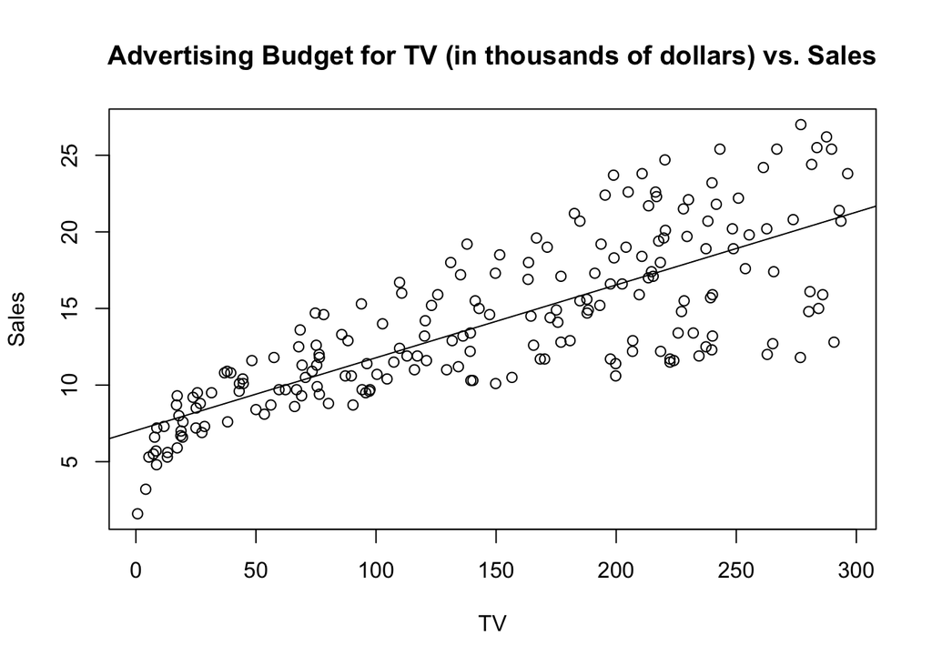

```r
m.TV.plot <- with(sales_advertising, plot(TV, Sales, main="Advertising Budget for TV (in thousands of dollars) vs. Sales"))
abline(m.TV)
```

```r
m.radio <-lm(Sales ~ Radio, data=sales_advertising)
summary(m.radio)
```

```
##
## Call:
## lm(formula = Sales ~ Radio, data = sales_advertising)
##
## Residuals:
##      Min       1Q   Median       3Q      Max
## -15.7305  -2.1324   0.7707   2.7775   8.1810
##
## Coefficients:
##             Estimate Std. Error t value Pr(>|t|)
## (Intercept)  9.31164    0.56290  16.542   <2e-16 ***
## Radio        0.20250    0.02041   9.921   <2e-16 ***
## ---
## Signif. codes:  0 '***' 0.001 '**' 0.01 '*' 0.05 '.' 0.1 ' ' 1
##
## Residual standard error: 4.275 on 198 degrees of freedom
## Multiple R-squared:  0.332,  Adjusted R-squared:  0.3287
## F-statistic: 98.42 on 1 and 198 DF,  p-value: < 2.2e-16
```

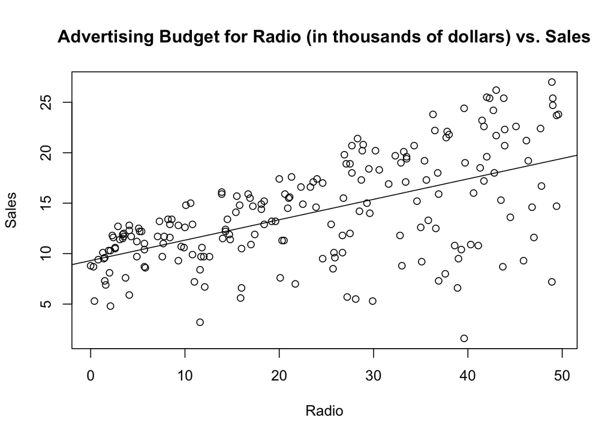

```r
m.radio.plot<- with(sales_advertising, plot(Radio, Sales, main="Advertising Budget for Radio (in thousands of dollars) vs. Sales"))
abline(m.radio)
```

```r
m.newspaper <- lm(Sales ~ Newspaper, data=sales_advertising)
summary(m.newspaper)
```

```
##
## Call:
## lm(formula = Sales ~ Newspaper, data = sales_advertising)
##
## Residuals:
##      Min       1Q   Median       3Q      Max
## -11.2272  -3.3873  -0.8392   3.5059  12.7751
##
## Coefficients:
##             Estimate Std. Error t value Pr(>|t|)
## (Intercept) 12.35141    0.62142   19.88  < 2e-16 ***
## Newspaper    0.05469    0.01658    3.30  0.00115 **
## ---
## Signif. codes:  0 '***' 0.001 '**' 0.01 '*' 0.05 '.' 0.1 ' ' 1
##
## Residual standard error: 5.092 on 198 degrees of freedom
## Multiple R-squared:  0.05212,    Adjusted R-squared:  0.04733
## F-statistic: 10.89 on 1 and 198 DF,  p-value: 0.001148
```

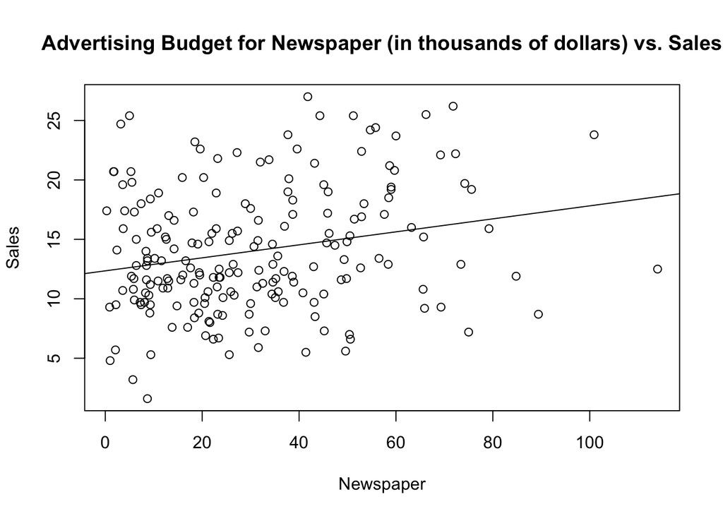

```r
m.newspaper.plot <- with(sales_advertising, plot(Newspaper, Sales, main="Advertising Budget for Newspaper (in thousands of dollars) vs. Sales"))
abline(m.newspaper)
```

```r
#Both the Sales vs. TV and  Sales vs. Radio showed a positive linear trend. Sales vs. Newspaper does not show a linear trend.
```

2. Perform a simple regression to model sales ~ TV. Write your code below. What is the observed association between sales and TV? What is the null hypothesis for this particular model? From the regression, what can we say about the null hypothesis? Use a p-value threshold of <0.05 to indicate significance.  
   Ans.

```r
# Insert code

m.sales_advertising <-lm(Sales~TV, data = sales_advertising)
summary(m.sales_advertising)
```

```
##
## Call:
## lm(formula = Sales ~ TV, data = sales_advertising)
##
## Residuals:
##     Min      1Q  Median      3Q     Max
## -8.3860 -1.9545 -0.1913  2.0671  7.2124
##
## Coefficients:
##             Estimate Std. Error t value Pr(>|t|)
## (Intercept) 7.032594   0.457843   15.36   <2e-16 ***
## TV          0.047537   0.002691   17.67   <2e-16 ***
## ---
## Signif. codes:  0 '***' 0.001 '**' 0.01 '*' 0.05 '.' 0.1 ' ' 1
##
## Residual standard error: 3.259 on 198 degrees of freedom
## Multiple R-squared:  0.6119, Adjusted R-squared:  0.6099
## F-statistic: 312.1 on 1 and 198 DF,  p-value: < 2.2e-16
```

```r
coef(m.sales_advertising)
```

```
## (Intercept)          TV
##  7.03259355  0.04753664
```

```r
confint(m.sales_advertising)
```

```
##                  2.5 %     97.5 %
## (Intercept) 6.12971927 7.93546783
## TV          0.04223072 0.05284256
```

```r
#βo = 7.03259, β1 = 0.04753
#(95% CI, 0.04-0.05, p<0.05)

#At zero dollars (in thousands of dollars) for the TV advertising budget, the average sales is 7033 units. With an increase by $1000 spent on TV advertising, the average sales is correlated with an increase in sales by 48 units.

#Ho = There is no significance between the sales and TV advertising budget (in thousands of dollars).
#Ha = There is a significance between the sales and TV advertising budget (in thousands of dollars).

#Since p-value < 0.05, we reject the Ho.
```

3. Perform a simple regression to model sales ~ newspaper. Write your code below. What is the observed association between sales and newspaper? What is the null hypothesis for this particular model? From the regression, what can we say about the null hypothesis? Use a p-value threshold of <0.05 to indicate significance.  
   Ans.

```r
# Insert code

m.sales_advertising <-lm(Sales~Newspaper, data = sales_advertising)
summary(m.sales_advertising)
```

```
##
## Call:
## lm(formula = Sales ~ Newspaper, data = sales_advertising)
##
## Residuals:
##      Min       1Q   Median       3Q      Max
## -11.2272  -3.3873  -0.8392   3.5059  12.7751
##
## Coefficients:
##             Estimate Std. Error t value Pr(>|t|)
## (Intercept) 12.35141    0.62142   19.88  < 2e-16 ***
## Newspaper    0.05469    0.01658    3.30  0.00115 **
## ---
## Signif. codes:  0 '***' 0.001 '**' 0.01 '*' 0.05 '.' 0.1 ' ' 1
##
## Residual standard error: 5.092 on 198 degrees of freedom
## Multiple R-squared:  0.05212,    Adjusted R-squared:  0.04733
## F-statistic: 10.89 on 1 and 198 DF,  p-value: 0.001148
```

```r
coef(m.sales_advertising)
```

```
## (Intercept)   Newspaper
##  12.3514071   0.0546931
```

```r
confint(m.sales_advertising)
```

```
##                   2.5 %      97.5 %
## (Intercept) 11.12595560 13.57685854
## Newspaper    0.02200549  0.08738071
```

```r
#βo = 12.3514, β1 = 0.0546
#(95% CI, 0.02-0.09, p<0.05)

#At zero dollars (in thousands of dollars) for the Newspaper advertising budget, the average sales is 12,351 units. With an increase by $1000 spent on Newspaper advertising, the average sales is correlated with an increase in sales by 55 units.

#Ho = There is no significance between the Newspaper advertising budget (in thousands of dollars) and sales.
#Ha = There is a significance between the Newspaper advertising budget (in thousands of dollars) and sales.

#Since p-value < 0.05, we reject the Ho.
```

4. Perform a multiple linear regression to model sales ~ TV + radio + newspaper.  
   Ans.

```r
# Insert code

m2.sales_advertising <-lm(Sales ~ TV + Radio + Newspaper, data = sales_advertising)

summary(m2.sales_advertising)
```

```
##
## Call:
## lm(formula = Sales ~ TV + Radio + Newspaper, data = sales_advertising)
##
## Residuals:
##     Min      1Q  Median      3Q     Max
## -8.8277 -0.8908  0.2418  1.1893  2.8292
##
## Coefficients:
##              Estimate Std. Error t value Pr(>|t|)
## (Intercept)  2.938889   0.311908   9.422   <2e-16 ***
## TV           0.045765   0.001395  32.809   <2e-16 ***
## Radio        0.188530   0.008611  21.893   <2e-16 ***
## Newspaper   -0.001037   0.005871  -0.177     0.86
## ---
## Signif. codes:  0 '***' 0.001 '**' 0.01 '*' 0.05 '.' 0.1 ' ' 1
##
## Residual standard error: 1.686 on 196 degrees of freedom
## Multiple R-squared:  0.8972, Adjusted R-squared:  0.8956
## F-statistic: 570.3 on 3 and 196 DF,  p-value: < 2.2e-16
```

```r
coef(m2.sales_advertising)
```

```
##  (Intercept)           TV        Radio    Newspaper
##  2.938889369  0.045764645  0.188530017 -0.001037493
```

```r
confint(m2.sales_advertising)
```

```
##                   2.5 %     97.5 %
## (Intercept)  2.32376228 3.55401646
## TV           0.04301371 0.04851558
## Radio        0.17154745 0.20551259
## Newspaper   -0.01261595 0.01054097
```

1. What are the observed associations between sales and each of the media budgets? Mention which associations are significant. Use a p-value threshold of <0.05 to indicate significance.  
   Ans.

βo = 2.94, βTV = 0.0458, βRadio = 0.19, βNewspaper = -0.001

TV: Holding all other variables constant, an increase by $1000 spent on the TV advertising budget is correlated with an increase of 46 units in sales. Since p-value < 0.05, this association is statistically significant.

Radio: Holding all other variables constant, an increase by $1000 spent on the Radio advertising budget is correlated with an increase of 189 units in sales. Since p-value < 0.05, this association is stastically significant.

Newspaper: Holding all other variables constant, an increase by $1000 spent on the Newspaper advertising budget is correlated with a decrease of 1 unit in sales. (p-value = 0.86) Since p-value > 0.05, this association is not stastically significant.

2. Do you observe any difference in the associations in the multiple regression model vs. the simple regression model? Explain why or why not.  
   Ans.

In the simple regression model for TV, Radio, and Newspaper, the β1 values (slope) were 0.05, 0.2, and 0.05. In the multiple regression model, the slopes were 0.05, 0.2, and -0.001. The Newspaper slope value in the multiple regression model was not signifiant (p-value = 0.86). Therefore, as “individual” predictors (TV, Radio, Newspaper), their relationship with the response (sales) is significant. When the Newspaper predictor interacts with the other individuals predictors (TV and Radio), the relationship is not stastically significant.